# Collection of validation data in the context of remote sensing based forest monitoring

Tutorial for the EON Summer School 2022

Paul Magdon[University of Applied Sciences and Arts (HAWK), paul.magdon@hawk.de]

2022-09-07

# Introduction

In this tutorial we will explore the principles of design-based sampling. The simulation part is based on a presentation of Gerad Heuveling from Wageningen University, which he gave in the OpenGeoHub Summer School[https://opengeohub.org/summer-school/ogh-summer-school-2021/].

1. Learn how to draw a spatial random sample
2. Learn how to draw a systematic grid for a given area of interest
3. Run a simulation for design-based sampling

# Data sets

For demonstration purposes we will work with a map of forest above ground biomass (AGB) produced by the Joint Research Center(JRC) for the European Union European Commission (Joint Research Centre (JRC) (2020) http://data.europa.eu/89h/d1fdf7aa-df33-49af-b7d5-40d226ec0da3.)

To provide a synthetic example we will assume that this map (agb_pop) is an error free representation of the population. Additionally we use a second map (agb_model) compiled using a machine learning model (RF) also depicting the AGB distribution.

```r
np_boundary = st_transform(st_read("data/nlp-harz_aussengrenze.gpkg"),25832)
agb_pop <- raster("data/agb_np_harz_truth.tif")

agb_model <-raster("data/agb_np_harz_model.tif")
```

If we assume the $z(x_i)=$ agb.pop to be an exact representation of the population we can calculate the Root mean Square Error (RMSE) as the difference between the model predictions $\hat{z(x_i)}$ and the population map with:

$$RMSE = \sqrt{\frac{1}{N}\sum{(z(x_{i})-\hat{z}(x_{i}))^2}}$$

```r
RMSE_pop = sqrt(cellStats((agb_pop-agb_model)^2, mean))
```

By looking at the difference from the “true” AGB and the difference we get a true RMSE of *41.23* t/ha.

# Collect a random sample

Since we know the true RMSE, we can test if a random sample estimate has a similar RMSE. We start with a random sample with $n=100$ sample points.

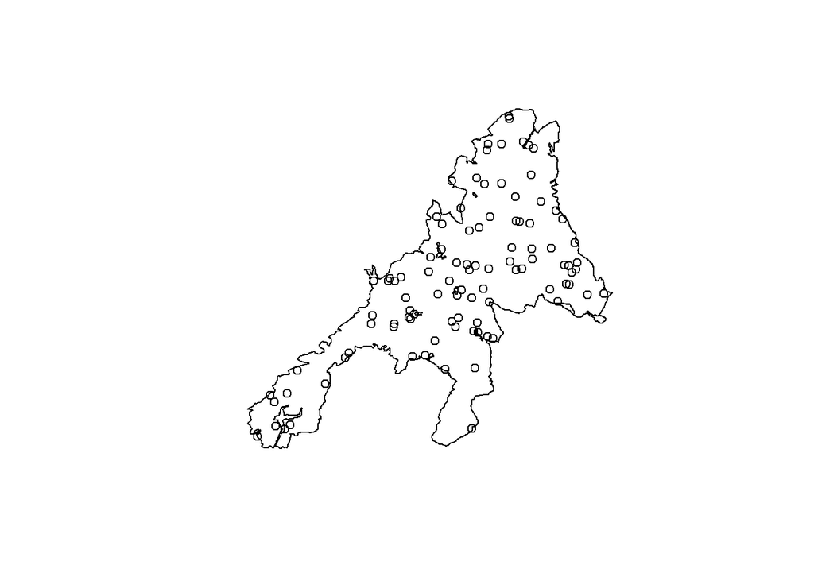

```r
n=100
p1 = st_sample(np_boundary,size=n)
plot(st_geometry(np_boundary))
plot(p1,add=TRUE,pch=1)
```

We can now extract the population values and the model values at the sample locations and calculate the RMSE for all sample points.

```r
sample <- raster::extract((agb_pop-agb_model),as_Spatial(p1))
RMSE_est <- sqrt(mean((sample)^2,na.rm=T))
```

The random sample estimates the RMSE as 41.99.

But is this an unbiased estimate?

# Simulation of many random samples

To check if our sample based estimates are unbiased we will repeat the sampling $k$ times.

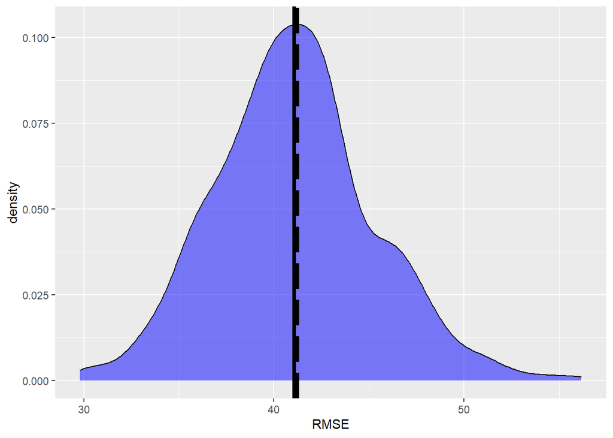

```r
dif <- as((agb_pop-agb_model), 'SpatialGridDataFrame')
seed<- 12324


k <- 500
n <- 50
RMSE <- rep(0,k)

for (i in 1:k) {
  #print(i)
  p1 = spsample(as_Spatial(np_boundary),n=n,type='random')
  crs(p1)<-crs(dif)
  #sample <- raster::extract((agb_pop-agb_model),p1)
  error<-over(p1,dif)$layer
  RMSE[i] <- sqrt(mean((error)^2,na.rm=T))
}

df <- data.frame(x=RMSE, y=rep('a',k))

ggplot(data=df,aes(x=x))+
  geom_density(data=subset(df,y=='a'),
               fill='blue', alpha=0.5)+
  xlab('RMSE')+geom_vline(xintercept=RMSE_pop,size=1.5,
                          color ='black', linetype='longdash')+
  geom_vline(xintercept=mean(df$x),size=1.5,
                          color ='black')
```

We see that the true RMSE and the mean of the $k$ simulation runs are almost equal. Thus, we can assume an unbiased estimate of the RMSE.

But how does the sample size $n$ affects the accuracy?

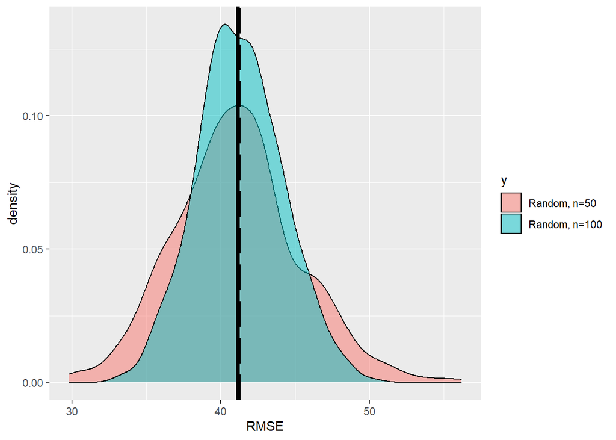

```r
k <- 500
n <- 100
RMSE_2 <- rep(0,k)

for (i in 1:k) {
  #print(i)
  p1 = spsample(as_Spatial(np_boundary),n=n,type='random')
  crs(p1)<-crs(dif)
  #sample <- raster::extract((agb_pop-agb_model),p1)
  error<-over(p1,dif)$layer
  RMSE_2[i] <- sqrt(mean((error)^2,na.rm=T))
}

df_2 <- data.frame(x=RMSE_2, y=rep('b',k))
df<-rbind(df,df_2)

ggplot(data=df,aes(x=x,fill=y))+
  geom_density(alpha=0.5)+
  scale_fill_discrete(labels=c('Random, n=50', 'Random, n=100'))+
  xlab('RMSE')+geom_vline(xintercept=RMSE_pop,size=1.5,
                          color ='black', linetype='longdash')+
  geom_vline(xintercept=mean(df$x),size=1.5,
                          color ='black')
```

We see that the precision of the esimtates is increased. How much did the uncertainty decrease when we increase the sample size from $n=50$ to $n=100$?

```r
sd(RMSE_2)/sd(RMSE)
```

```
## [1] 0.6912253
```

# Systematic sampling

Instead of a random sampling, systematic designs are more common in forest inventories for the following reasons:

- Easy to establish and to document
- Ensures a balanced spatial coverage

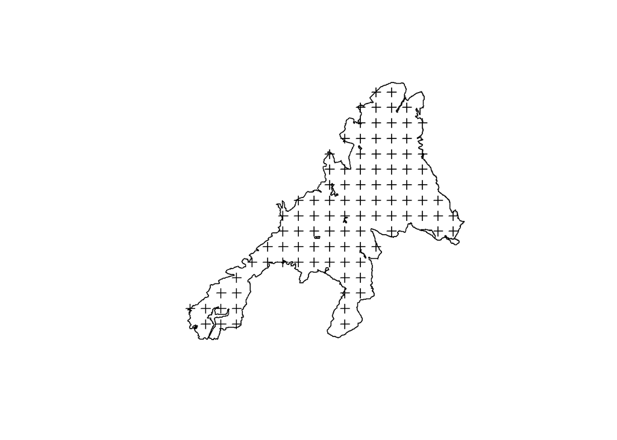

```r
p1 = spsample(as_Spatial(np_boundary),n=n,type='regular')

plot(np_boundary$geom)
plot(p1, add=T)
```

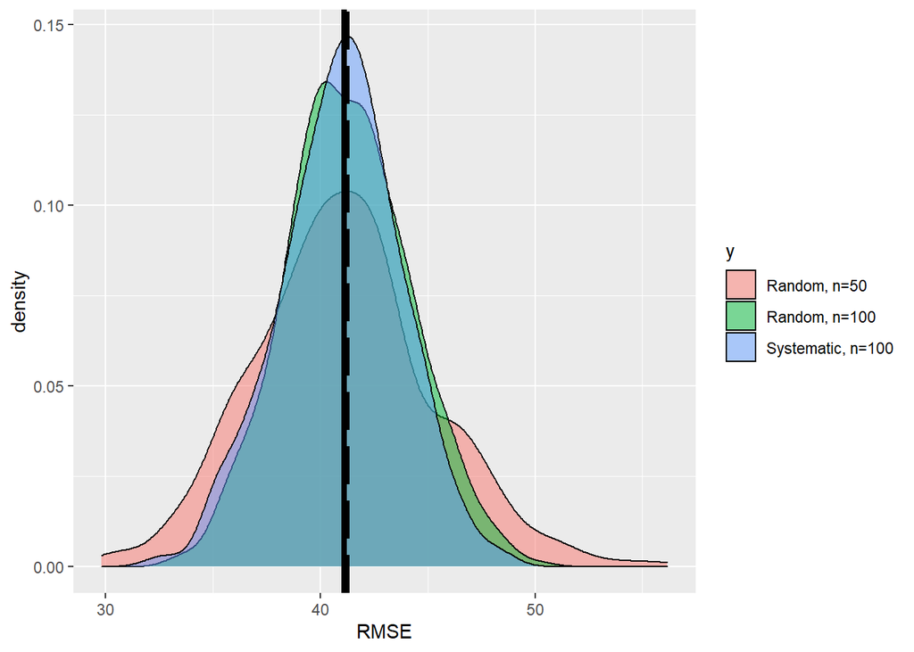

```r
k <- 500
n <- 100
RMSE_3 <- rep(0,k)

for (i in 1:k) {
  #print(i)
  p1 = spsample(as_Spatial(np_boundary),n=n,type='regular')
  crs(p1)<-crs(dif)
  error<-over(p1,dif)$layer
  RMSE_3[i] <- sqrt(mean((error)^2,na.rm=T))
}

df_3<- data.frame(x=RMSE_3, y=rep('c',k))
df<-rbind(df,df_3)

ggplot(data=df,aes(x=x, fill=y))+
  geom_density(alpha=0.5)+
  scale_fill_discrete(labels=c('Random, n=50', 'Random, n=100','Systematic, n=100'))+
  xlab('RMSE')+geom_vline(xintercept=RMSE_pop,size=1.5,
                          color ='black', linetype='longdash')+
  geom_vline(xintercept=mean(df$x),size=1.5,
                       color ='black')
```